# Lab 2: Use of Deadly Force by Police

Matt Robinson & Vincent Lee

9/26/2016

## R Markdown

The following lines of code import necessary libraries to execute this code:

### Preparation / Imports

```r
install.packages("devtools")
install.packages("flexdashboard")
install.packages("lubridate")
install.packages("dplyr")
install.packages("ggplot2")
devtools::install_github("lionel-/ggstance")
install.packages("ggalt")
```

```r
library(devtools)
library(flexdashboard)
library(lubridate)
library(dplyr)
library(ggplot2)
library(ggstance)
library(ggalt)
```

## Introduction

For this lab, we took a look at the use of deadly force by police officers in the United States. This analysis is based on the work of Julia Silge’s “data flex-dashboard”.

- **Link to Article:** https://www.r-bloggers.com/fatal-police-shootings-across-the-u-s/
- **Link to the Dashboard Visualization:** https://gist.github.com/juliasilge/9acbe97c549502bac85404779edceba0
- **Link to the Washington Post Visualization** https://www.washingtonpost.com/graphics/national/police-shootings/
- **Link to Github:** https://github.com/washingtonpost/data-police-shootings

The data we imported is a compilation of every fatal shooting in the United States by a police officer in the line of duty from a database organized by the Washington Post since Jan. 1, 2015.

*Since 2015, The Washington Post has recorded dozens of details about each killing:*

- **id**: unique id of the person
- **name**: first, middle, and last name of the person
- **date** the date of the fatal shooting
- **manner_of_death**: description of whether they were Beaten or Shot
- **armed**: whether the person killed was armed
- **age**: person’s age
- **gender**: Male or Female
- **race**: includes the race of the deceased
- **city**: location of city area
- **state**: location of state
- **threat level**: the circumstances of the shooting
- **signs_of_mental_illness**: whether the victim was experiencing a mental-health crisis
- **flee**: were they running away by Foot, Not Fleeing, Car, Other
- **body_camera**: was the victim recorded by a body camera

In 2016, The Washington post went to gather additional information about each fatal shooting that occurred during this year. There were reports, websites, and social media that have been constantly monitoring independent databases about fatal police shootings. More than a dozen additional details were collected about the officers and victims in each individual shooting. As of right now, there is a continuous live web tracking service that records the number of Fatal Police Shootings in 2016.

In this lab assignment, we want to look at the data set to make an in-depth analysis on the different demographic, date, location, and circumstances of death within Fatal Police Shootings Data.

## Analysis

We imported the data set obtained from the Washington Post police shootings database. Then, we clean up the code by changing dates, genders, races, and manners of death to an understandable format.

```r
fatalshootings <- read.csv("./fatal-police-shootings-data.csv", stringsAsFactors = FALSE)
fatalshootings$date <- ymd(fatalshootings$date)
fatalshootings[,c(4:5,7:8,9:14)] <- lapply(fatalshootings[,c(4:5,7:8,9:14)], as.factor)
levels(fatalshootings$gender) <- c("Female", "Male")
levels(fatalshootings$race) <- c("Unknown", "Asian", "Black", "Hispanic", "Unknown", "Other", "White")
fatalshootings$race <- factor(fatalshootings$race, levels(fatalshootings$race)[c(5,2,1,4,3,6)])
levels(fatalshootings$flee) <- c("Unknown", "Car", "Foot", "Not fleeing", "Other")
fatalshootings$flee <- factor(fatalshootings$flee, levels(fatalshootings$flee)[c(1,5,3,2,4)])
levels(fatalshootings$manner_of_death) <- c("Beaten", "Shot", "Shot/Tasered")
fatalshootings$manner_of_death <- factor(fatalshootings$manner_of_death, levels(fatalshootings$manner_of_death)[c(1,3,2)])
```

Once we have our clean data, we are ready to start creating interesting visualizations using ggplot.

### Demographic Analysis

#### Deaths by Race/Ethnicity

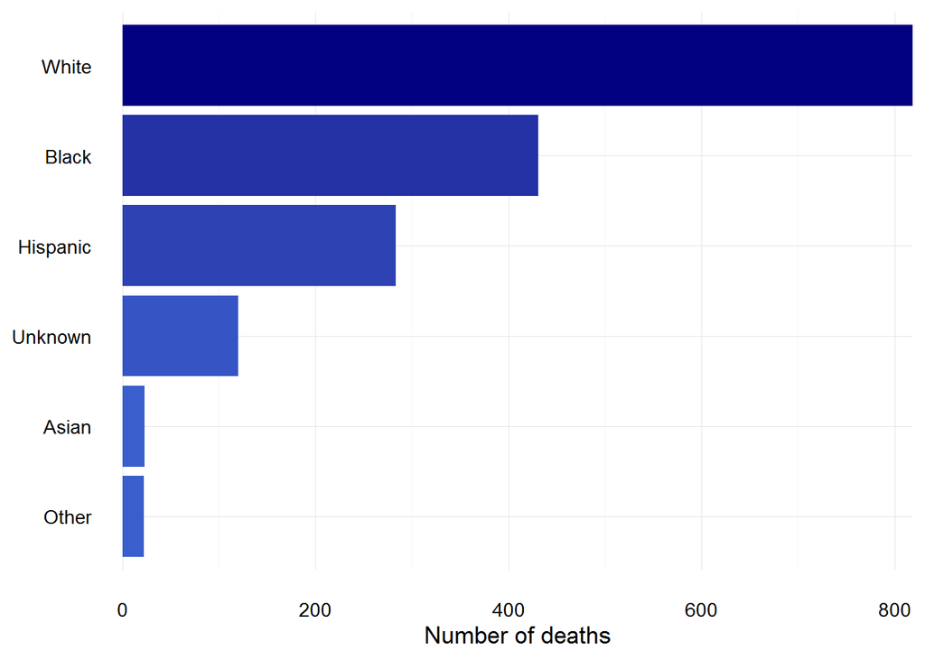

[output not shown]

```r
ggplot(data = fatalshootings, aes(y = race)) +
        geom_barh(aes(fill = ..count..)) +
        theme_minimal(base_size = 13) +
        theme(legend.position = "none") +
        scale_x_continuous(expand=c(0,0)) +
        scale_fill_gradient(low = "royalblue3", high = "navyblue") +
        labs(y = NULL, x = "Number of deaths")
```

#### Deaths by Gender

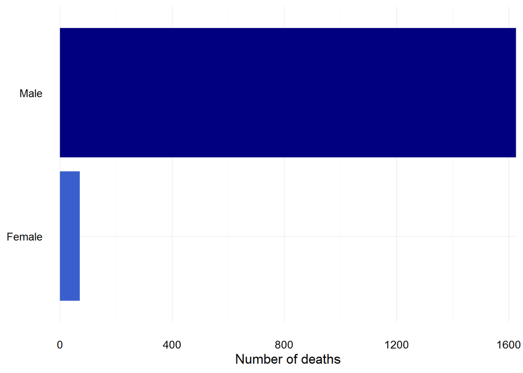

```
Clearly, male victims fall into the greater number of fatal police shootings. Further investigation is needed since the male ratio deaths are overwhelmingly higher than the females. Why are males approached with more violence and deaths than females?
```

```r
ggplot(data = fatalshootings, aes(y = gender)) +
        geom_barh(aes(fill = ..count..)) +
        theme_minimal(base_size = 13) +
        theme(legend.position = "none") +
        scale_x_continuous(expand=c(0,0)) +
        scale_fill_gradient(low = "royalblue3", high = "navyblue") +
        labs(y = NULL, x = "Number of deaths")
```

#### Deaths by Age

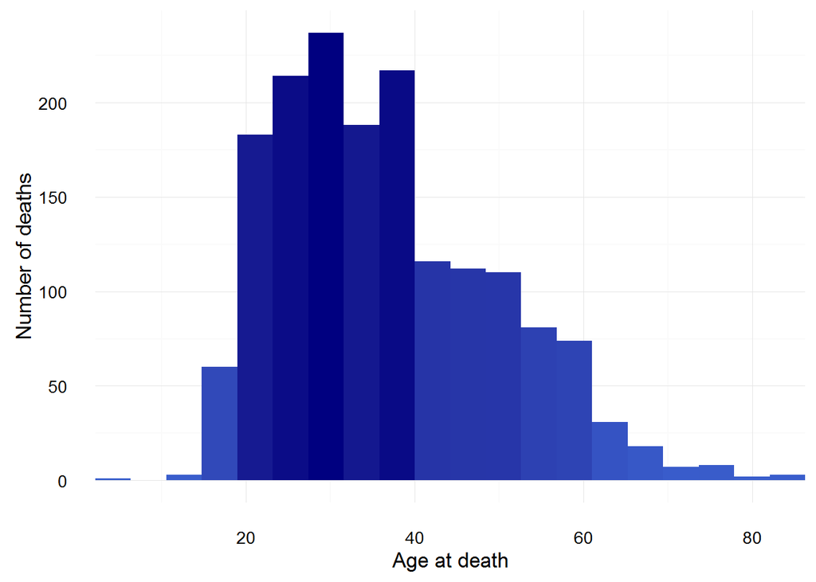

[output not shown]

```r
ggplot(data = fatalshootings, aes(x = age)) +
        geom_histogram(aes(fill = ..count..), bins = 20) +
        theme_minimal(base_size = 13) +
        theme(legend.position = "none") +
        scale_x_continuous(expand=c(0,0)) +
        scale_fill_gradient(low = "royalblue3", high = "navyblue") +
        labs(x = "Age at death", y = "Number of deaths")
```

#### Deaths based on mental illness

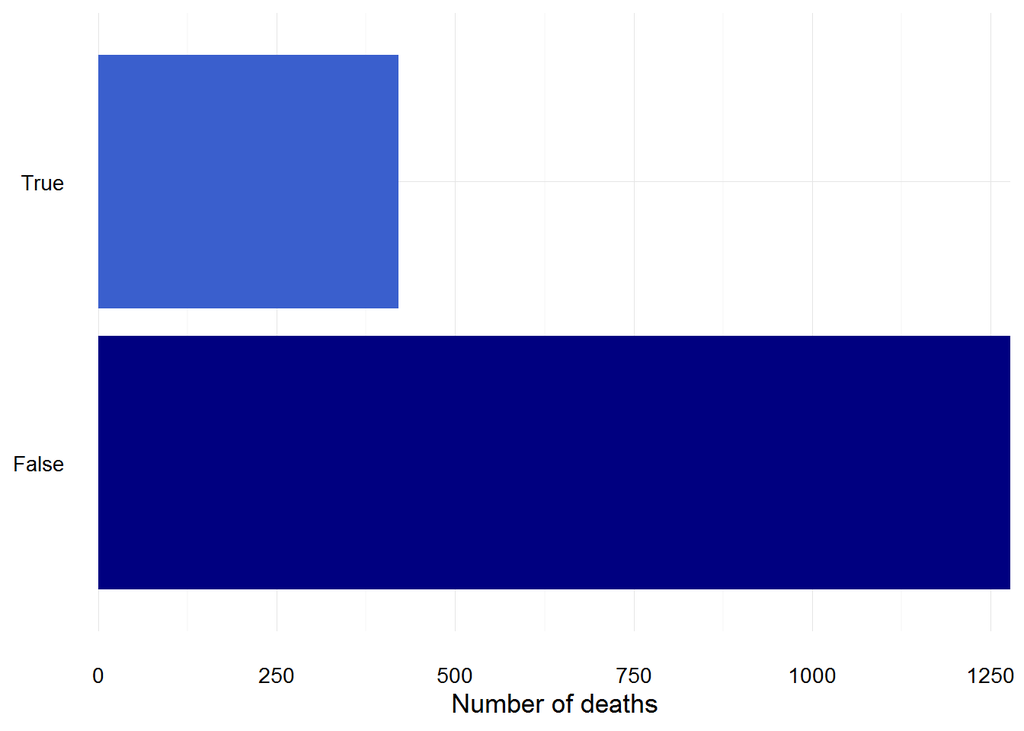

```r
ggplot(data = fatalshootings, aes(y = signs_of_mental_illness)) +
        geom_barh(aes(fill = ..count..)) +
        theme_minimal(base_size = 13) +
        theme(legend.position = "none") +
        scale_x_continuous(expand=c(0,0)) +
        scale_fill_gradient(low = "royalblue3", high = "navyblue") +
        labs(y = NULL, x = "Number of deaths")
```

```r
# I would add the percentages or proportions onto the graph
summary(fatalshootings$signs_of_mental_illness)
```

```
## False  True
##  1278   420
```

```r
(420/1698)
```

```
## [1] 0.2473498
```

```
A significant proportion of death is based on mental illness. Could there be some bias in the data collection? What considers to be a mental illness? Is the medical report verified before or after the fatal shooting incident?
```

### Date of Shootings

#### Overall

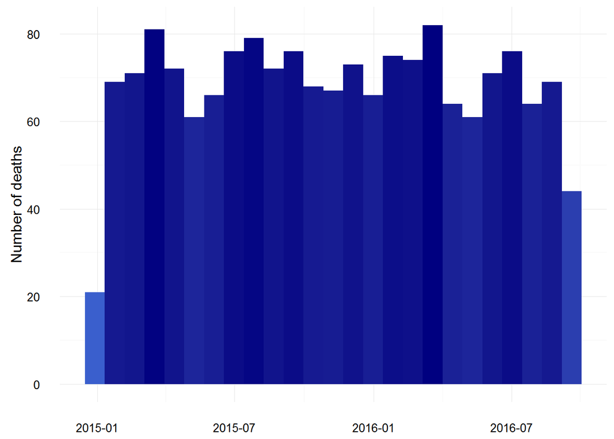

```r
ggplot(data = fatalshootings, aes(x = date)) +
        geom_histogram(aes(fill = ..count..), bins = 25) +
        theme_minimal() +
        theme(legend.position = "none") +
        scale_fill_gradient(low = "royalblue3", high = "navyblue") +
        labs(x = NULL, y = "Number of deaths")
```

#### Deaths by Month

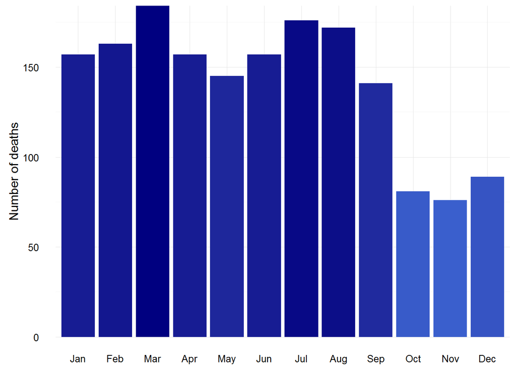

```r
ggplot(data = fatalshootings, aes(x = month(date, label = TRUE))) +
        geom_bar(aes(fill = ..count..)) +
        theme_minimal() +
        theme(legend.position = "none") +
        scale_y_continuous(expand=c(0,0)) +
        scale_fill_gradient(low = "royalblue3", high = "navyblue") +
        labs(x = NULL, y = "Number of deaths")
```

#### Deaths by Day of Week

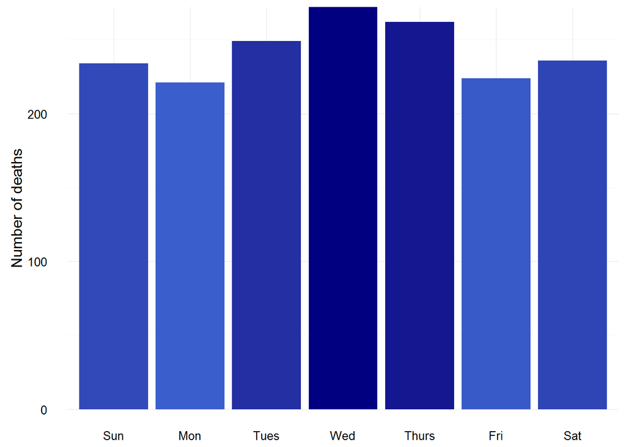

[output not shown]

```r
ggplot(data = fatalshootings, aes(x = wday(date, label = TRUE))) +
        geom_bar(aes(fill = ..count..)) +
        theme_minimal() +
        theme(legend.position = "none") +
        scale_y_continuous(expand=c(0,0)) +
        scale_fill_gradient(low = "royalblue3", high = "navyblue") +
        labs(x = NULL, y = "Number of deaths")
```

### Location Breakdown

#### Deaths by State

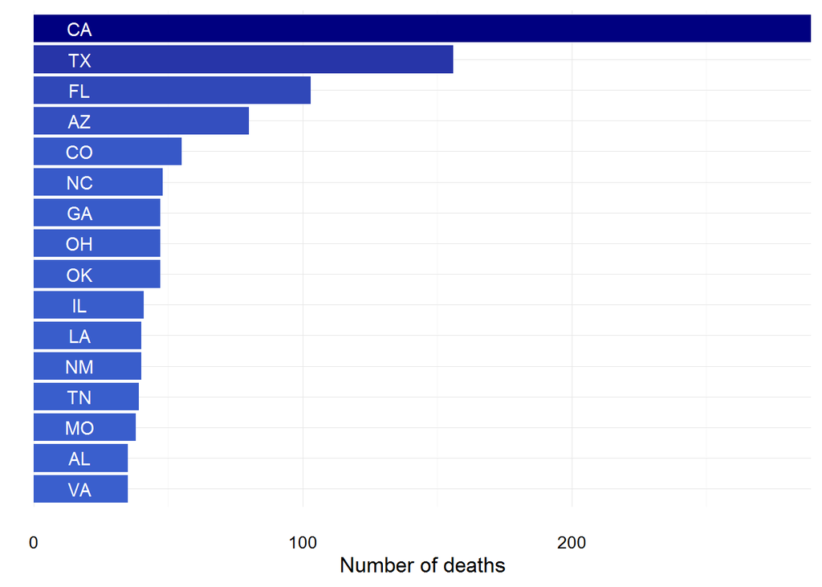

[output not shown]

```r
stateinfo <- fatalshootings %>% group_by(state) %>% summarise(n = n()) %>%
        arrange(desc(n)) %>% top_n(15) %>%
        mutate(state = factor(state, levels = rev(unique(state))))
ggplot(stateinfo, aes(x = n, y = state)) +
        geom_barh(stat="identity", aes(fill = n)) +
        #geom_stateface(aes(y=state, x=7, label=as.character(state)), colour="white", size=8) +
        geom_text(aes(x = 17, y = state, label=as.character(state)), color="white", size=4) +
        labs(y = NULL, x = "Number of deaths") +
        scale_fill_gradient(low = "royalblue3", high = "navyblue") +
        theme_minimal(base_size = 13) +
        theme(axis.text.y=element_blank()) +
        theme(legend.position = "none") +
        scale_x_continuous(expand=c(0,0))
```

### Was The Person Killed Armed

#### Was the victim armed?

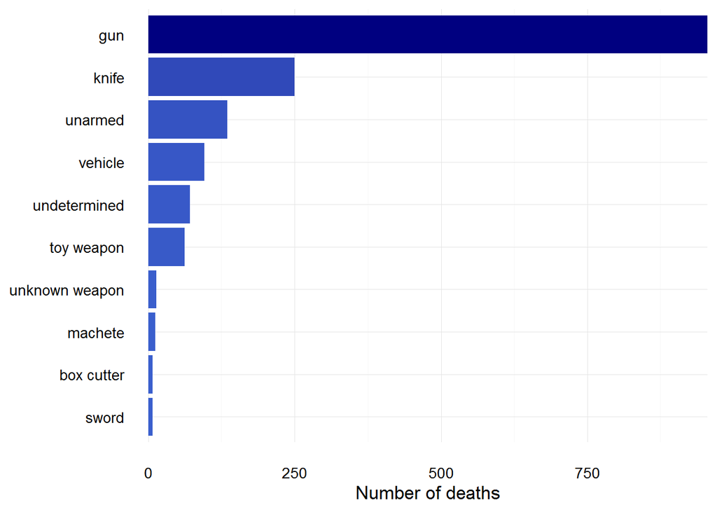

```
There were a great number of unusually recored weapons. It makes sense that the data describes most fatal shootings would occur when victim holding out a gun. However, it does not make sense that there is still a moderately high ratio of deaths for victims who are completely unarmed.
```

```r
armedinfo <- fatalshootings %>% group_by(armed) %>% summarise(n = n()) %>%
        arrange(desc(n)) %>% top_n(10) %>%
        mutate(armed = factor(armed, levels = rev(unique(armed))))

ggplot(data = armedinfo, aes(x = n, y = armed)) +
        geom_barh(stat="identity", aes(fill = n)) +
        theme_minimal(base_size = 13) +
        theme(legend.position = "none") +
        scale_x_continuous(expand=c(0,0)) +
        scale_fill_gradient(low = "royalblue3", high = "navyblue") +
        labs(y = NULL, x = "Number of deaths")
```

### Circumstances of Death

#### Was the officer wearing a body camera?

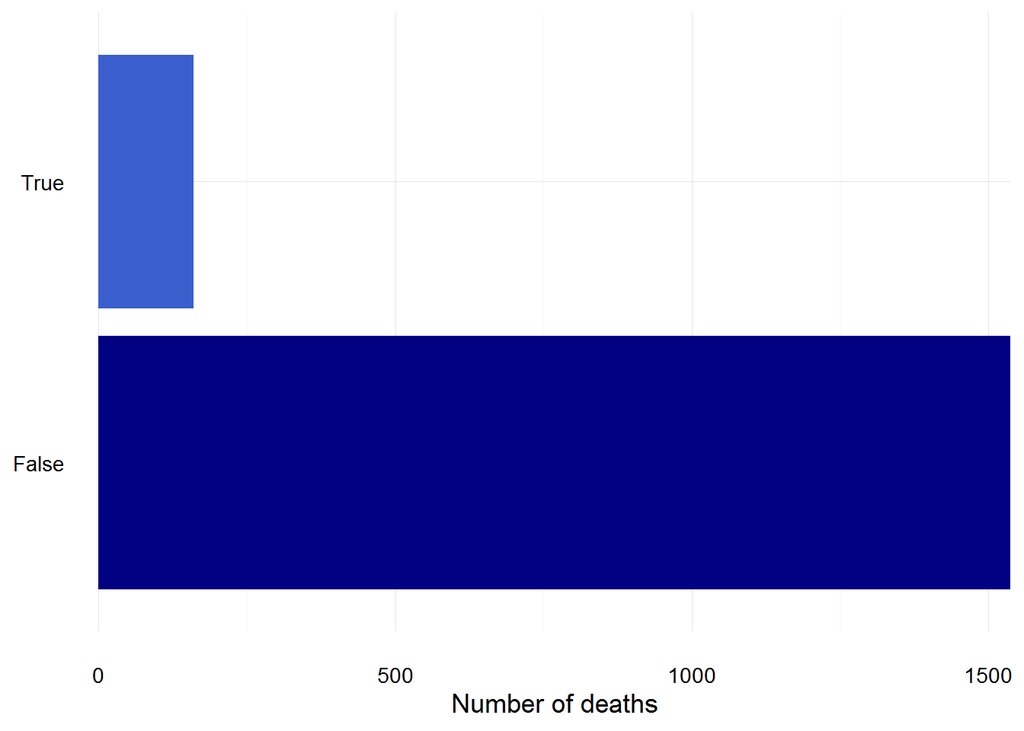

[output not shown]

```r
ggplot(data = fatalshootings, aes(y = body_camera)) +
        geom_barh(aes(fill = ..count..)) +
        theme_minimal(base_size = 13) +
        theme(legend.position = "none") +
        scale_x_continuous(expand=c(0,0)) +
        scale_fill_gradient(low = "royalblue3", high = "navyblue") +
        labs(y = NULL, x = "Number of deaths")
```

#### Was the victim fleeing?

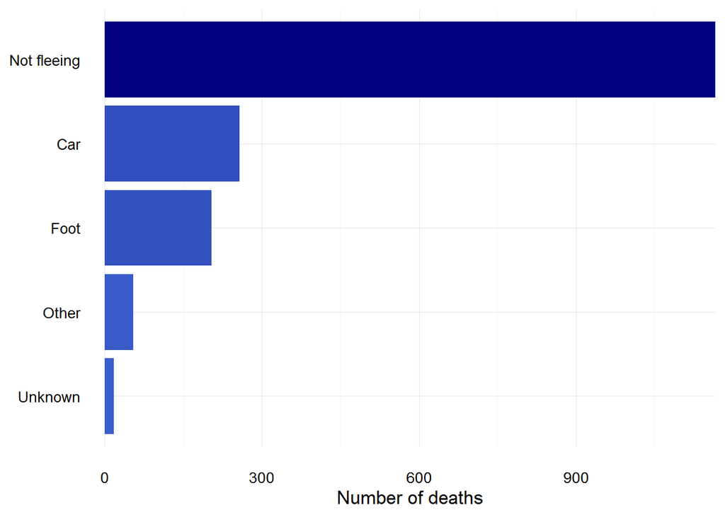

```
Great visualization that shows the amount of victims fleeing or not fleeing during the scene. Again, how do you 'categorize' unknown column if we also have a column called 'other'.
```

```r
ggplot(data = fatalshootings, aes(y = flee)) +
        geom_barh(aes(fill = ..count..)) +
        theme_minimal(base_size = 13) +
        theme(legend.position = "none") +
        scale_x_continuous(expand=c(0,0)) +
        scale_fill_gradient(low = "royalblue3", high = "navyblue") +
        labs(y = NULL, x = "Number of deaths")
```

#### How was the person killed?

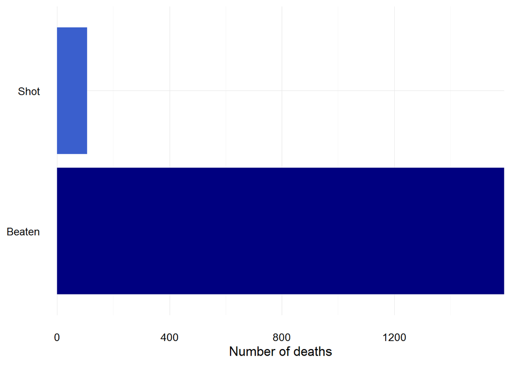

[output not shown]

```r
ggplot(data = fatalshootings, aes(y = manner_of_death)) +
        geom_barh(aes(fill = ..count..)) +
        theme_minimal(base_size = 13) +
        theme(legend.position = "none") +
        scale_x_continuous(expand=c(0,0)) +
        scale_fill_gradient(low = "royalblue3", high = "navyblue") +
        labs(y = NULL, x = "Number of deaths")
```

### Follow Up

#### Death per Capita Breakdown

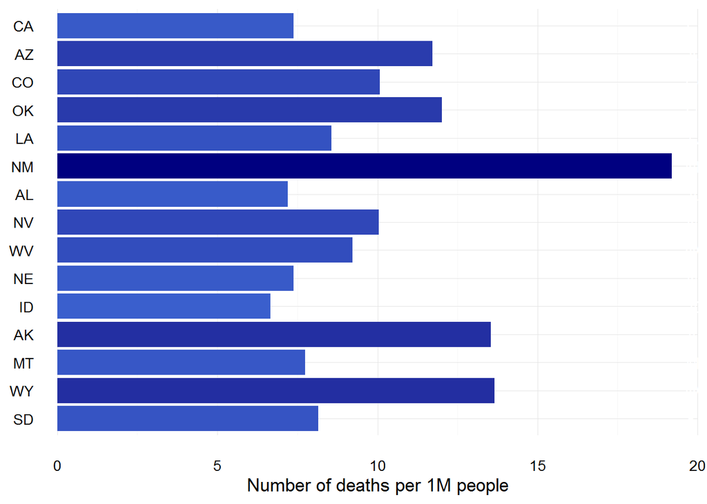

```r
stateinfo <- fatalshootings %>% group_by(state) %>% summarise(n = n()) %>%
  arrange(desc(n)) %>%
  mutate(state = factor(state, levels = rev(unique(state))))

census <- read.csv('./NST-EST2015-alldata.csv', stringsAsFactors = FALSE)
census <- transform(census, state = state.abb[match(census$NAME,state.name)])
stateinfo <- merge(stateinfo,census,by="state")
stateinfo$dPerCap <- stateinfo$n / (stateinfo$POPESTIMATE2015 / 1000000)
stateinfo <- stateinfo %>% arrange(desc(dPerCap)) %>% top_n(15)

ggplot(stateinfo, aes(x = dPerCap, y = state)) +
  geom_barh(stat="identity", aes(fill = dPerCap)) +
  geom_text(aes(x = 20, y = state, label=as.character(state)), color="white", size=4) +
  labs(y = NULL, x = "Number of deaths per 1M people") +
  scale_fill_gradient(low = "royalblue3", high = "navyblue") +
  theme_minimal(base_size = 13) +
  theme(legend.position = "none") +
  scale_x_continuous(expand=c(0,0))
```

Simple analysis without making graphical models or bar charts.

```r
table(fatalshootings$armed)
```

```
##
##                                                                ax
##                                2                                6
##                     baseball bat baseball bat and fireplace poker
##                                4                                1
##                            baton                          bayonet
##                                1                                1
##                     bean-bag gun                      beer bottle
##                                1                                1
##                     blunt object                       box cutter
##                                2                                7
##                            brick                          carjack
##                                1                                1
##                            chain                        chain saw
##                                1                                2
##               contractor's level                   cordless drill
##                                1                                1
##                         crossbow                         flagpole
##                                3                                1
##                       flashlight                      garden tool
##                                1                                1
##                      glass shard                              gun
##                                1                              955
##                    gun and knife              guns and explosives
##                                2                                3
##                           hammer                       hand torch
##                                6                                1
##                          hatchet                  hatchet and gun
##                                5                                1
##                            knife                 lawn mower blade
##                              250                                1
##                          machete                     meat cleaver
##                               12                                2
##                  metal hand tool                     metal object
##                                1                                1
##                       metal pipe                       metal pole
##                                4                                2
##                      metal stick                       motorcycle
##                                2                                1
##                         nail gun                         pick-axe
##                                1                                1
##                    piece of wood                             pipe
##                                1                                1
##                        pitchfork                             pole
##                                1                                1
##                             rock                         scissors
##                                1                                2
##                      screwdriver                     sharp object
##                                3                                1
##                           shovel                            spear
##                                2                                1
##                          stapler              straight edge razor
##                                1                                1
##                            sword                            Taser
##                                7                                6
##                       toy weapon                          unarmed
##                               62                              135
##                     undetermined                   unknown weapon
##                               71                               14
##                          vehicle
##                               96
```

```r
table(fatalshootings$manner_of_death)
```

```
##
##       Beaten Shot/Tasered         Shot
##         1591            0          107
```

```r
table(fatalshootings$age)
```

```
##
##  6 12 13 14 15 16 17 18 19 20 21 22 23 24 25 26 27 28 29 30 31 32 33 34 35
##  1  1  1  1  4  9 13 34 28 27 36 45 47 54 63 46 51 51 65 56 65 41 45 50 52
## 36 37 38 39 40 41 42 43 44 45 46 47 48 49 50 51 52 53 54 55 56 57 58 59 60
## 64 41 41 37 34 33 28 32 23 41 27 25 19 30 30 27 23 26 20 17 18 13 14 24 13
## 61 62 63 64 65 66 67 68 69 70 71 72 74 75 76 77 80 82 83 86
## 10  8 13  6  4  4  4  4  6  2  3  2  1  1  4  2  1  1  1  2
```

```r
table(fatalshootings$gender)
```

```
##
## Female   Male
##     71   1627
```

```r
table(fatalshootings$race)
```

```
##
##    Other    Asian  Unknown Hispanic    Black    White
##       22       23      120      283      431      819
```

```r
table(fatalshootings$state)
```

```
##
##  AK  AL  AR  AZ  CA  CO  CT  DC  DE  FL  GA  HI  IA  ID  IL  IN  KS  KY
##  10  35  12  80 289  55   6   8   4 103  47   7   9  11  41  27  15  29
##  LA  MA  MD  ME  MI  MN  MO  MS  MT  NC  ND  NE  NH  NJ  NM  NV  NY  OH
##  40  17  24   3  25  22  38  15   8  48   2  14   4  22  40  29  32  47
##  OK  OR  PA  RI  SC  SD  TN  TX  UT  VA  VT  WA  WI  WV  WY
##  47  25  31   2  31   7  39 156  17  35   3  34  28  17   8
```

```r
table(fatalshootings$signs_of_mental_illness)
```

```
##
## False  True
##  1278   420
```

```r
table(fatalshootings$threat_level)
```

```
##
##       attack        other undetermined
##         1131          479           88
```

```r
table(fatalshootings$flee)
```

```
##
##     Unknown       Other        Foot         Car Not fleeing
##          17          54         204         257        1166
```

```r
table(fatalshootings$body_camera)
```

```
##
## False  True
##  1537   161
```

## Conclusion

```
- One of the lessons that we learned early on was that proper data wrangling made it easier to proceed with our Data Visualization
- We could've used the opportunity to reorder Julie's graphs in order to interpret some other underlying  information that we may have missed in our original analysis
- We could've definitely looked into using other variables for supporting our Data Analysis.
- There could have been issues or bias with the data provided. However outliers and misinformation are caveats for the importance of proper data collection and analysis.
- If we had time, the stretch goal was to create a graphical map visualization or an interactive visualization where people can hover over and see the data (choroplethr or googleVis).
```